# Fisseha Berhane, PhD

#### Data Scientist

443-970-2353 fisseha@jhu.edu CV Resume

Level Of Detail (LOD) Expressions in Tableau help us to define at what level of detail aggregations should be made. They are very helpful in the Tableau world. As we know, Tableau is manily drag and drop with some minimal coding. However, in R or Python to create a visualization, we have to explicitly program it. In this post and in the next one, I am trying to compare how easy it is to perfrom Tableau’s LOD expressions in R. This post can be helpful for someone who knows Tableau and wants to study R or for someone who knows R and wants to understand Tableau's LOD expressions. The data is from Tableau’s website. You can download it from [here](http://www.tableau.com/sites/default/files/training/global_superstore.zip). After downloading it, don’t forget to unzip it. We will formulate questions and solve them using both R and Tableau’s Level of Detail Expressions. You can download the Tableau visualizations to see the calculated fields that use LOD expressions. I have also included screenshots of the calculated fields.

I am using the **dplyr** R package for data manipulation as it is more intuitive. However, if you want succint code and also faster package, specially for large volume queries and aggregations, check out the **data.table** package. The **lubridate** package is used to parse dates and the **plotly** package is used to make our R visualizations interactive so that we can compare the R and Tableau results by hovering.

#### Load libraries

```r
suppressMessages(library(tidyverse))
suppressMessages(library(data.table))
suppressMessages(library(plotly))
suppressMessages(library(lubridate))
```

#### Import Data

```r
Sample_Superstore = fread("Sample_Superstore_orders.csv")
```

#### Understand the columns

```r
str(Sample_Superstore)
```

```
Classes 'data.table' and 'data.frame':  9994 obs. of  21 variables:
 $ Row ID       : int  1 2 3 4 5 6 7 8 9 10 ...
 $ Order ID     : chr  "CA-2013-152156" "CA-2013-152156" "CA-2013-138688" "US-2012-108966" ...
 $ Order Date   : chr  "11/9/2013" "11/9/2013" "6/13/2013" "10/11/2012" ...
 $ Ship Date    : chr  "11/12/2013" "11/12/2013" "6/17/2013" "10/18/2012" ...
 $ Ship Mode    : chr  "Second Class" "Second Class" "Second Class" "Standard Class" ...
 $ Customer ID  : chr  "CG-12520" "CG-12520" "DV-13045" "SO-20335" ...
 $ Customer Name: chr  "Claire Gute" "Claire Gute" "Darrin Van Huff" "Sean O'Donnell" ...
 $ Segment      : chr  "Consumer" "Consumer" "Corporate" "Consumer" ...
 $ Country      : chr  "United States" "United States" "United States" "United States" ...
 $ City         : chr  "Henderson" "Henderson" "Los Angeles" "Fort Lauderdale" ...
 $ State        : chr  "Kentucky" "Kentucky" "California" "Florida" ...
 $ Postal Code  : int  42420 42420 90036 33311 33311 90032 90032 90032 90032 90032 ...
 $ Region       : chr  "South" "South" "West" "South" ...
 $ Product ID   : chr  "FUR-BO-10001798" "FUR-CH-10000454" "OFF-LA-10000240" "FUR-TA-10000577" ...
 $ Category     : chr  "Furniture" "Furniture" "Office Supplies" "Furniture" ...
 $ Sub-Category : chr  "Bookcases" "Chairs" "Labels" "Tables" ...
 $ Product Name : chr  "Bush Somerset Collection Bookcase" "Hon Deluxe Fabric Upholstered Stacking Chairs, Rounded Back" "Self-Adhesive Address Labels for Typewriters by Universal" "Bretford CR4500 Series Slim Rectangular Table" ...
 $ Sales        : num  262 731.9 14.6 957.6 22.4 ...
 $ Quantity     : int  2 3 2 5 2 7 4 6 3 5 ...
 $ Discount     : num  0 0 0 0.45 0.2 0 0 0.2 0.2 0 ...
 $ Profit       : num  41.91 219.58 6.87 -383.03 2.52 ...
 - attr(*, ".internal.selfref")=<externalptr>
```

Let’s change Order Date and Ship Date to appropriate date format. They are imported as character.

```r
Sample_Superstore$`Order Date` = mdy(Sample_Superstore$`Order Date`)
Sample_Superstore$`Ship Date` = mdy(Sample_Superstore$`Ship Date`)
```

### 1. How many days each month are highly profitable, profitable, or unprofitable?

If daily profit is more than $200, let’s consider it highly profitable.

Note: The plots below are interactive. You can hover over it to see values.

```r
temp = Sample_Superstore %>%  group_by(`Order Date`) %>% summarise(DailyProfit = sum(Profit)) %>%
mutate(Profitability = ifelse(DailyProfit  > 200, "Highly Profitable",
                             ifelse(DailyProfit   < 0, "Unprofitable", "Profitable")))

temp = temp %>% mutate(Year = year(`Order Date`),
                       Month = month(`Order Date`, label = TRUE, abbr = TRUE))

temp = temp %>% group_by(Profitability, Year, Month) %>% summarise(Count = n())

g = temp %>% ggplot(aes(x = Month, y = Count)) +
               facet_grid(Profitability ~ Year) + geom_bar(stat = "identity", aes(fill = Profitability)) +
               theme(strip.text.y = element_blank(), axis.title = element_blank(),
                    axis.text.x = element_text(angle = 60))
ggplotly(g)
```

[interactive chart not shown]

### Tableau solution of the above question:

[figure not shown]

#### Screenshots of calculated fields used to create the above Tableau visualization are shown below.

[figure not shown]

### 2. What percent of customers ordering items in 2013 also ordered items in 2014?

```r
customers_2014 = Sample_Superstore %>% filter(year(`Order Date`)==2014)

customers_2013_in_2014 = Sample_Superstore %>% filter(year(`Order Date`)==2013) %>%
                              filter(`Customer ID` %in% unique(customers_2014$`Customer ID`))

customers_2013_not_in_2014 = Sample_Superstore %>% filter(year(`Order Date`)==2013) %>%
                              filter(!(`Customer ID` %in% unique(customers_2014$`Customer ID`)))

temp = length(unique(customers_2013_in_2014$`Customer ID`))/ ( length(unique(customers_2013_in_2014$`Customer ID`)) +
                                                       length(unique(customers_2013_not_in_2014$`Customer ID`)))*100
message(paste0(round(temp, 2), "% of customers ordering items in 2013 also ordered items in 2014"))
```

```
## 87.44% of customers ordering items in 2013 also ordered items in 2014
```

### Tableau solution of the above question:

[figure not shown]

### 3. How many customers made more than 10 orders?

```r
 temp = Sample_Superstore %>% distinct(`Customer ID`, `Order ID`) %>%
                  group_by(`Customer ID`) %>% summarise(Total = n()) %>%
                  filter(Total > 10) %>% nrow()

message(paste0(round(temp, 2), " customers made more than 10 orders"))
```

```
## 49 customers made more than 10 orders
```

### Tableau solution of the above question:

[figure not shown]

### 4. A single order can include multiple items across multiple product categories. Each item will be on a different row of the data, but the rows will share a single Order ID. Find the average sales value for orders which include Technology.

```r
technology = Sample_Superstore %>% filter(Category =="Technology")

technology_Order_IDs = unique(technology$`Order ID`)

orders_containing_technology =  Sample_Superstore %>% filter(`Order ID` %in% technology_Order_IDs)

temp = sum(orders_containing_technology$Sales)/(length(unique(technology_Order_IDs)))

message(paste0("Average sales value for orders which include Technology: ", round(temp, 2)))
```

```
## Average sales value for orders which include Technology: 822
```

### Tableau solution of the above question:

[figure not shown]

### 5. How many days in March 2013 had positive profit?

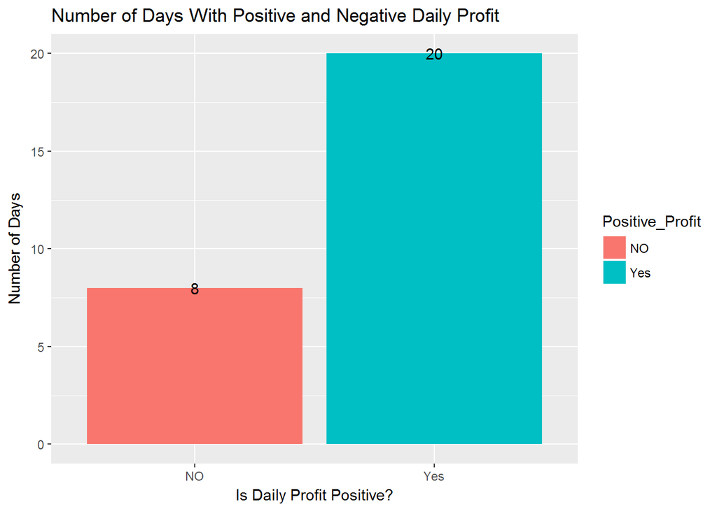

```r
 Sample_Superstore %>% filter(year(`Order Date`)==2013 , month(`Order Date`)==3) %>%
            group_by(`Order Date`) %>% summarise(Total_Profit = sum(Profit)) %>%
            mutate(Positive_Profit = ifelse(Total_Profit > 0,  "Yes", "NO" )) %>%
            group_by(Positive_Profit) %>% summarise(Count = n()) %>%
            ggplot(aes(x = Positive_Profit, y = Count, fill = Positive_Profit)) + geom_bar(stat = "identity") +
             geom_text(aes(label = Count)) + xlab("Is Daily Profit Positive?") + ylab("Number of Days") +
             ggtitle("Number of Days With Positive and Negative Daily Profit")
```

### Tableau solution of the above question:

[figure not shown]

#### Screenshots of calculated fields used to create the above Tableau visualization are shown below.

[figure not shown]

### 6. How many customers have made 1, 2, 3, N orders?

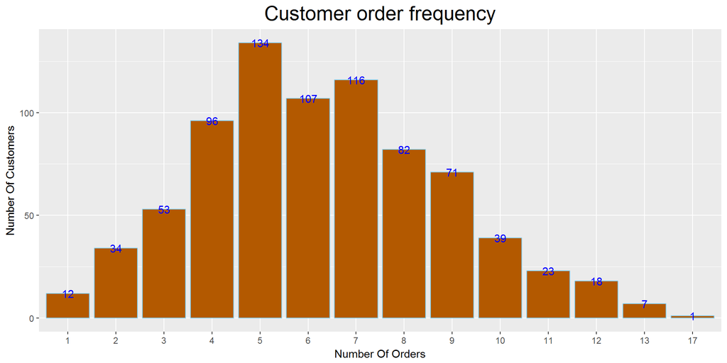

```r
 Sample_Superstore %>% distinct(`Customer ID`, `Order ID`) %>%
                  group_by(`Customer ID`) %>% summarise(Number_of_orders = n()) %>%
                  mutate(Number_of_orders = as.factor(Number_of_orders)) %>%
                  group_by(Number_of_orders) %>% summarise(Number_of_customers = n()) %>%
                  ggplot(aes(x = Number_of_orders, y = Number_of_customers)) +
                  geom_bar(stat="identity",color='skyblue',fill='#b35900') +
                  geom_text(aes(label = Number_of_customers), color = "blue") +
                  xlab("Number Of Orders") + ylab("Number Of Customers") +
                  ggtitle("Customer order frequency") +
                 theme(plot.title = element_text(size = 20, hjust = 0.5))
```

### Tableau solution of the above question:

[figure not shown]

#### Screenshots of calculated fields used to create the above Tableau visualization are shown below.

[figure not shown]

### 7. How much revenue is contributed annually by each customer cohort?

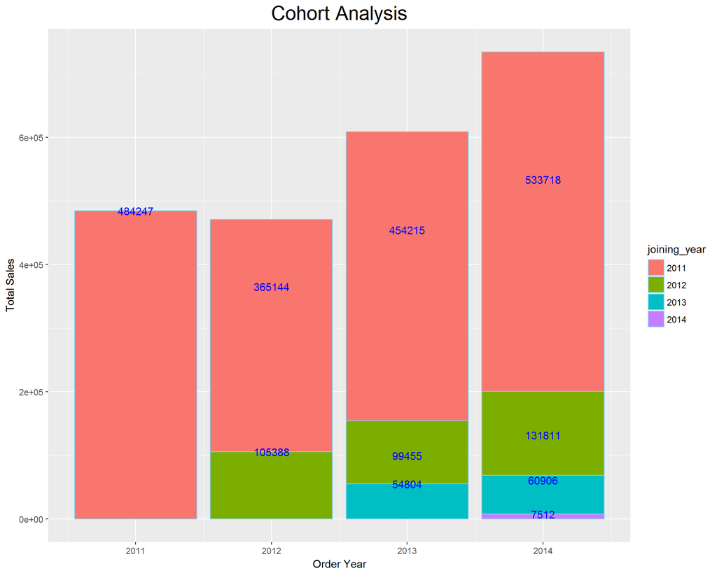

```r
 Sample_Superstore %>% inner_join(
                              Sample_Superstore %>% group_by(`Customer ID`) %>%
                              summarise(joining_year = year(min(`Order Date`))), by = "Customer ID") %>%
                   mutate(joining_year = as.factor(joining_year)) %>%
                   group_by(Order_Year = year(`Order Date`), joining_year) %>% summarise(Total_Sales  = round(sum(Sales), 0)) %>%
                   ggplot(aes(x = Order_Year, y = Total_Sales, fill = joining_year )) +
                   geom_bar(stat="identity",color='skyblue') + geom_text(aes(label = Total_Sales), color = "blue") +
                   xlab("Order Year") + ylab("Total Sales") + ggtitle("Cohort Analysis") +
                 theme(plot.title = element_text(size = 20, hjust = 0.5))
```

### Tableau solution of the above question:

[figure not shown]

#### Screenshots of calculated fields used to create the above Tableau visualization are shown below.

[figure not shown]

### 8. What is the percentage of sales by state of the top five states?

```r
sales_over_all = sum(Sample_Superstore$Sales)

Sample_Superstore %>% group_by(State) %>% summarise(Total_sales  = sum(Sales)/sales_over_all*100) %>%
                    arrange(desc(Total_sales)) %>% head(5) %>% mutate(Total_sales = round(Total_sales,1))
```

```
# A tibble: 5 x 2
         State Total_sales
         <chr>       <dbl>
1   California        19.9
2     New York        13.5
3        Texas         7.4
4   Washington         6.0
5 Pennsylvania         5.1
```

### Tableau solution of the above question:

[figure not shown]

### 9. What is the trend of number of customers we’ve acquired per day per state for the top five states by sales?

```r
top_five_states_by_sales = Sample_Superstore %>% group_by(State) %>% summarise(Total_sales= sum(Sales)) %>%
                             arrange(desc(Total_sales)) %>% head(5) %>% .$State

temp = Sample_Superstore %>% inner_join(
                         Sample_Superstore %>% group_by(`Customer ID`) %>%
                         summarise(first_order_date = min(`Order Date`)),
                         by = "Customer ID") %>%
               mutate(New = ifelse(`Order Date`==first_order_date, "Yes", "NO")) %>% filter(New =="Yes") %>%
               filter(State %in% top_five_states_by_sales) %>%
               distinct(`Customer ID`, .keep_all = TRUE) %>% group_by(State, `Order Date`) %>%
               summarise(New_Customers = n())

df = data_frame()

for(state in top_five_states_by_sales ){
    z = temp %>% filter(State ==state)
    z$New_Customers = cumsum(z$New_Customers)
    df = bind_rows(df, z)
}

gg = df %>% ggplot(aes(x = `Order Date`, y = New_Customers, color = State)) + geom_line()

ggplotly(gg)
```

[interactive chart not shown]

### Tableau solution of the above question:

[figure not shown]

#### Screenshots of calculated fields used to create the above Tableau visualization are shown below.

[figure not shown]

#### How did you get this blog post? Don’t hesitate to comment below if you have any questions or suggestions. I will see you in the next part.

[comments powered by Disqus](http://disqus.com)